# Predição de deputados eleitos

Paulo Vinicius Soares

26 de fevereiro de 2018

## Introdução

Essa semana iremos utilizar mais uma vez os dados sobre deputados e tentaremos prever se este deputado será eleito ou não com base nos atributos que temos na nossa base de dados.

```r
library(readr)
library(knitr)
library(tidyverse)
library(caret)
source("../utils/importa_dados_deputados.R")
```

Vamos importar os dados dos deputados. Vamos retirar, além disso, algumas variáveis que não possuem tanta influência no modelo (Visto previamente em análise). Vamos adicionar três novos campos para otimizar a geração dos modelos: is_deputado, is_homem e is_superior_completo. Essas variáveis são derivadas de descricao_ocupacao, sexo e grau, respectivamente. Como estas variáveis possuem muitos fatores, o mais sensato é derivar os fatores que tem maior influência para reduzir o tempo de produção do modelo.

```r
deputados <- get_kaggle_data() %>%
  mutate(is_deputado = ifelse(descricao_ocupacao=="DEPUTADO",TRUE,FALSE),
         is_homem = ifelse(sexo=="MASCULINO",TRUE,FALSE),
         is_superior_completo=ifelse(grau=="SUPERIOR COMPLETO",TRUE,FALSE)) %>%
  select(-nome, -numero_cadidato, -setor_economico_despesa, -setor_economico_receita,
         -partido,-UF,-total_despesa,-idade,-estado_civil,-descricao_cor_raca,-descricao_ocupacao,-sexo,-grau)
```

# Perguntas

## 1.Há desbalanceamento das classes (isto é, uma classe tem muito mais instâncias que outra)? Em que proporção? Quais efeitos colaterais o desbalanceamento de classes pode causar no classificador?

Para responder essa pergunta utilizaremos um histograma que contará a frequência de deputados eleitos e não eleitos.

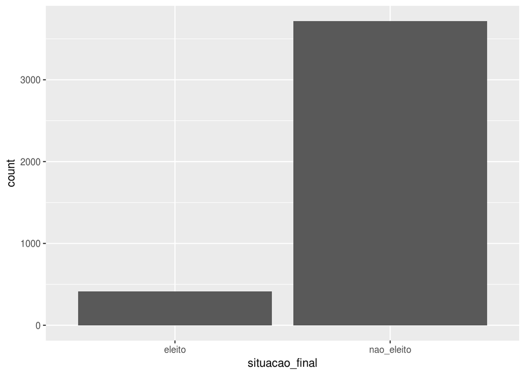

```r
# Frequência de eleitos e não eleitos
deputados %>%
  ggplot(aes(situacao_final)) + geom_histogram(stat="count")
```

Podemos observar que há um claro desbalanceamento entre as classes, havendo muito mais deputados não eleitos do que deputados eleitos. Os riscos que essa situação acarreta, em primeira instância, é o perigo de enviesamento da previsão para uma das classes presentes nos dados. Como a proporção de deputados eleitos para não eleitos é de aproximadamente 500 para 3500, é muito provável que ele preveja “não eleito” para determinados casos. Isso pode ocorrer ao utilizar os algoritmos de Árvore de Decisão. As soluções para esse tipo de problema são o *undersampling* da classe majoritária ou o *oversampling* da classe minoritária. O *undersampling* consiste em retirar amostras da classe que possui maior frequência a fim de igualar as observações com a classe de menor frequência. O *oversampling* consiste em aumentar o número de observações da amostra de menor frequência através de reamostragem. Aqui a estratégia adotada será o *oversampling* para evitar a perda de informações.

## 2.Treine: um modelo de regressão logística, uma árvore de decisão e um modelo de adaboost. Tune esses modelos usando validação cruzada e controle overfitting se necessário, considerando as particularidades de cada modelo.

Vamos utilizar o pacote do Caret para dividir os dados em treino e teste.

```r
# Dividir os dados em treino e teste
set.seed(123)
dataPartition <- createDataPartition(y = deputados$situacao_final, p=0.75, list=FALSE)

treino <- deputados[dataPartition,]
teste <- deputados[-dataPartition,]
```

Vamos adotar a estratégia de oversampling no próprio Caret utilizando o parâmetro *sampling = up*.

```r
# Validação cruzada
# fitControlUndersampling <- trainControl(method = "repeatedcv", number = 5, repeats = 5, sampling="down")
fitControlOversampling <- trainControl(method = "repeatedcv", number = 5, repeats = 5, sampling="up")

preProcessing <- c("scale", "center", "nzv")

formula_modelo <- as.formula(situacao_final ~ . - ID)
```

### Regressão logística

Utilizando o modelo de Regressão Logística, temos:

```r
# modelo_regressao <- train(formula_modelo, data = treino, method="glm", family="binomial",
#                           na.action = na.omit, trControl = fitControlOversampling, preProcess = preProcessing)
# saveRDS(modelo_regressao, file = "modelo_regressao.rds")
modelo_regressao <- readRDS("modelo_regressao.rds")
```

### Árvore de decisão

Utilizando o modelo de Árvore De Regressão, temos:

```r
# modelo_arvore <- train(formula_modelo, data=treino, method="rpart", na.action = na.omit,
#                        trControl = fitControlOversampling, preProcess = preProcessing, cp=0.001, maxdepth=20)
#
# saveRDS(modelo_arvore, file = "modelo_arvore.rds")
modelo_arvore <- readRDS("modelo_arvore.rds")
```

### Adaboost

Utilizando o modelo Adaboost, temos:

```r
# modelo_adaboost <- train(formula_modelo, data=treino, method="adaboost", na.action = na.omit,
#                          preProcess = preProcessing)
# saveRDS(modelo_adaboost, file = "modelo_adaboost.rds")

modelo_adaboost <- readRDS("modelo_adaboost.rds")
```

## 3.Reporte acurácia, precision, recall e f-measure no treino e validação. Como você avalia os resultados? Justifique sua resposta.

Esses parâmetros são calculados em termos de Verdadeiros Positivos (TP), Verdadeiros Negativos (TN), Falsos Positivos (FP) e Falsos Negativos (FN).

A acurácia geralmente é dada no cálculo da matriz de confusão. Os demais parâmetros são calculados da seguinte forma:

```r
precision <- function(tp,fp){
  tp/(tp+fp)
}

recall <- function(tp,fn){
  tp/(tp+fn)
}

f_measure <- function(precision, recall) {
  2*((precision*recall)/(precision+recall))
}
```

Analisando cada modelo, temos:

### Regressão logística

Para os dados de treino, o modelo retorna os seguintes parâmetros:

```r
summary(modelo_regressao)
```

```
##
## Call:
## NULL
##
## Deviance Residuals:
##     Min       1Q   Median       3Q      Max
## -2.3862  -0.2006   0.0101   0.3744   5.0535
##
## Coefficients:
##                                        Estimate Std. Error z value
## (Intercept)                            -1.26468    0.09285 -13.621
## quantidade_doacoes                     -0.08615    0.25713  -0.335
## quantidade_doadores                    -0.76684    0.20114  -3.813
## total_receita                          33.54765   18.38699   1.825
## media_receita                          -0.39938    0.13963  -2.860
## recursos_de_outros_candidatos.comites  -6.96031    3.06717  -2.269
## recursos_de_partidos                  -19.98242   10.43006  -1.916
## recursos_de_pessoas_físicas            -5.66619    2.53669  -2.234
## recursos_de_pessoas_juridicas         -16.39327    8.06723  -2.032
## recursos_proprios                      -8.11479    4.19126  -1.936
## quantidade_despesas                    -2.35314    0.50870  -4.626
## quantidade_fornecedores                 2.59677    0.38439   6.756
## media_despesa                          -0.60851    0.09940  -6.122
## despesa_max_campanha                    0.26942    0.05578   4.830
## is_deputadoTRUE                        -0.92964    0.07004 -13.272
## is_homemTRUE                           -0.27348    0.05772  -4.738
## is_superior_completoTRUE               -0.42972    0.05314  -8.086
##                                       Pr(>|z|)
## (Intercept)                            < 2e-16 ***
## quantidade_doacoes                    0.737606
## quantidade_doadores                   0.000138 ***
## total_receita                         0.068072 .
## media_receita                         0.004233 **
## recursos_de_outros_candidatos.comites 0.023250 *
## recursos_de_partidos                  0.055384 .
## recursos_de_pessoas_físicas           0.025503 *
## recursos_de_pessoas_juridicas         0.042145 *
## recursos_proprios                     0.052853 .
## quantidade_despesas                   3.73e-06 ***
## quantidade_fornecedores               1.42e-11 ***
## media_despesa                         9.25e-10 ***
## despesa_max_campanha                  1.37e-06 ***
## is_deputadoTRUE                        < 2e-16 ***
## is_homemTRUE                          2.16e-06 ***
## is_superior_completoTRUE              6.15e-16 ***
## ---
## Signif. codes:  0 '***' 0.001 '**' 0.01 '*' 0.05 '.' 0.1 ' ' 1
##
## (Dispersion parameter for binomial family taken to be 1)
##
##     Null deviance: 7735.5  on 5579  degrees of freedom
## Residual deviance: 2770.3  on 5563  degrees of freedom
## AIC: 2804.3
##
## Number of Fisher Scoring iterations: 8
```

Na validação utilizando os dados de teste, temos:

```r
predictions_regressao <- predict(modelo_regressao, teste)
matriz_regressao <- confusionMatrix(predictions_regressao, teste$situacao_final)
matriz_regressao
```

```
## Confusion Matrix and Statistics
##
##             Reference
## Prediction   eleito nao_eleito
##   eleito         94         67
##   nao_eleito     10        862
##
##                Accuracy : 0.9255
##                  95% CI : (0.9077, 0.9407)
##     No Information Rate : 0.8993
##     P-Value [Acc > NIR] : 0.00224
##
##                   Kappa : 0.6689
##  Mcnemar's Test P-Value : 1.75e-10
##
##             Sensitivity : 0.9038
##             Specificity : 0.9279
##          Pos Pred Value : 0.5839
##          Neg Pred Value : 0.9885
##              Prevalence : 0.1007
##          Detection Rate : 0.0910
##    Detection Prevalence : 0.1559
##       Balanced Accuracy : 0.9159
##
##        'Positive' Class : eleito
##
```

A acurácia nos é dada pelo próprio modelo, que é de 92%, com intervalo de confiança de 95%. A precisão e o Recall são dados abaixo:

```r
prec_reg <- precision(tp = matriz_regressao$table[1], fp = matriz_regressao$table[3])
prec_reg
```

```
## [1] 0.5838509
```

```r
rec_reg <- recall(matriz_regressao$table[1], fn = matriz_regressao$table[2])
rec_reg
```

```
## [1] 0.9038462
```

```r
f_measure(precision = prec_reg, recall = rec_reg)
```

```
## [1] 0.709434
```

### Árvores de Decisão

Para os dados de treino, o modelo retorna os seguintes parâmetros:

```r
modelo_arvore
```

```
## CART
##
## 3102 samples
##   17 predictors
##    2 classes: 'eleito', 'nao_eleito'
##
## Pre-processing: scaled (16), centered (16)
## Resampling: Cross-Validated (5 fold, repeated 5 times)
## Summary of sample sizes: 2481, 2481, 2482, 2482, 2482, 2482, ...
## Addtional sampling using up-sampling prior to pre-processing
##
## Resampling results across tuning parameters:
##
##   cp          Accuracy   Kappa
##   0.02083333  0.8973544  0.5972906
##   0.06250000  0.8973544  0.5972906
##   0.32692308  0.8973544  0.5972906
##
## Accuracy was used to select the optimal model using the largest value.
## The final value used for the model was cp = 0.3269231.
```

A acurácia para os dados de treino foi de aproximadamente 90%, de forma semelhante para os testes.

Na validação utilizando os dados de teste, temos:

```r
predictions_arvore <- predict(modelo_arvore, teste)
matriz_arvore <- confusionMatrix(predictions_arvore, teste$situacao_final)
matriz_arvore
```

```
## Confusion Matrix and Statistics
##
##             Reference
## Prediction   eleito nao_eleito
##   eleito         97         92
##   nao_eleito      7        837
##
##                Accuracy : 0.9042
##                  95% CI : (0.8846, 0.9214)
##     No Information Rate : 0.8993
##     P-Value [Acc > NIR] : 0.3248
##
##                   Kappa : 0.6117
##  Mcnemar's Test P-Value : <2e-16
##
##             Sensitivity : 0.9327
##             Specificity : 0.9010
##          Pos Pred Value : 0.5132
##          Neg Pred Value : 0.9917
##              Prevalence : 0.1007
##          Detection Rate : 0.0939
##    Detection Prevalence : 0.1830
##       Balanced Accuracy : 0.9168
##
##        'Positive' Class : eleito
##
```

```r
prec_arv <- precision(tp = matriz_arvore$table[1], fp = matriz_arvore$table[3])
prec_arv
```

```
## [1] 0.5132275
```

```r
rec_arv <- recall(tp = matriz_arvore$table[1], fn = matriz_arvore$table[2])
rec_arv
```

```
## [1] 0.9326923
```

```r
f_measure(precision = prec_arv, recall = rec_arv)
```

```
## [1] 0.662116
```

### Adaboost

Para os dados de treino, o modelo retorna os seguintes parâmetros:

```r
modelo_adaboost
```

```
## AdaBoost Classification Trees
##
## 3102 samples
##   17 predictors
##    2 classes: 'eleito', 'nao_eleito'
##
## Pre-processing: scaled (16), centered (16)
## Resampling: Bootstrapped (25 reps)
## Summary of sample sizes: 3102, 3102, 3102, 3102, 3102, 3102, ...
## Resampling results across tuning parameters:
##
##   nIter  method         Accuracy   Kappa
##    50    Adaboost.M1    0.9404770  0.6515709
##    50    Real adaboost  0.9401343  0.6429888
##   100    Adaboost.M1    0.9398010  0.6464661
##   100    Real adaboost  0.9424094  0.6579842
##   150    Adaboost.M1    0.9402244  0.6492197
##   150    Real adaboost  0.9424528  0.6596178
##
## Accuracy was used to select the optimal model using the largest value.
## The final values used for the model were nIter = 150 and method =
##  Real adaboost.
```

Na validação utilizando os dados de teste, temos:

```r
predictions_adaboost <- predict(modelo_adaboost, teste)
matriz_adaboost <- confusionMatrix(predictions_adaboost, teste$situacao_final)
matriz_adaboost
```

```
## Confusion Matrix and Statistics
##
##             Reference
## Prediction   eleito nao_eleito
##   eleito         70         29
##   nao_eleito     34        900
##
##                Accuracy : 0.939
##                  95% CI : (0.9226, 0.9528)
##     No Information Rate : 0.8993
##     P-Value [Acc > NIR] : 3.976e-06
##
##                   Kappa : 0.6559
##  Mcnemar's Test P-Value : 0.6143
##
##             Sensitivity : 0.67308
##             Specificity : 0.96878
##          Pos Pred Value : 0.70707
##          Neg Pred Value : 0.96360
##              Prevalence : 0.10068
##          Detection Rate : 0.06776
##    Detection Prevalence : 0.09584
##       Balanced Accuracy : 0.82093
##
##        'Positive' Class : eleito
##
```

```r
prec_ada <- precision(tp = matriz_adaboost$table[1], fp = matriz_adaboost$table[3])
prec_ada
```

```
## [1] 0.7070707
```

```r
rec_ada <- recall(tp = matriz_adaboost$table[1], fn = matriz_adaboost$table[2])
rec_ada
```

```
## [1] 0.6730769
```

```r
f_measure(precision = prec_ada, recall = rec_ada)
```

```
## [1] 0.6896552
```

## 5. Envie os melhores modelos para o Kaggle:

```r
# dados_teste <- get_kaggle_data_test() %>%
#   mutate(is_deputado = ifelse(descricao_ocupacao=="DEPUTADO",TRUE,FALSE),
#          is_homem = ifelse(sexo=="MASCULINO",TRUE,FALSE),
#          is_superior_completo=ifelse(grau=="SUPERIOR COMPLETO",TRUE,FALSE)) %>%
#   select(-nome, -numero_cadidato, -setor_economico_despesa, -setor_economico_receita,
#          -partido,-UF,-total_despesa,-idade,-estado_civil,-descricao_cor_raca,-descricao_ocupacao,-sexo,-grau)
#
#
# predictions_regressao_teste_kaggle <- predict(modelo_regressao, dados_teste)
#
# dados_teste$situacao_final <- predictions_regressao_teste_kaggle
#
# dados_teste %>%
#   select(ID, prediction = situacao_final) %>%
#   write.csv("respostas.csv", row.names = FALSE)
#
# pred_adaboost <- predict(modelo_adaboost, dados_teste)
# dados_teste$situacao_final <- pred_adaboost
# model_rf <- train(formula_modelo, data = treino, method="rf", na.action = na.omit,
#                   trControl = fitControlOversampling, preProcess = preProcessing, prox = TRUE, allowParallel=TRUE)
```